# Store24

Prince Barai

February 13, 2018

# Store24 (A): Managing Employee Retention

TASK 4c - Download and review the “Store24.csv” data file associated with this case. Using R, read the data into a data frame called store.Using R, get the summary statistics of the data.Confirm that the summary statistics generated from R are consistent with Exhibit 3 from the Case.

```r
setwd("C:/Users/prince_pratik7/Desktop/Machine Learning/Data Analytics/Data Visualisation/Week 3 Day 1")
```

# Reading the DataSet in R

```r
store.df <-read.csv(paste ("Store24.csv", sep=""))
```

# Summary of Dastaset

```r
summary(store.df)
```

```
##      store          Sales             Profit          MTenure
##  Min.   : 1.0   Min.   : 699306   Min.   :122180   Min.   :  0.00
##  1st Qu.:19.5   1st Qu.: 984579   1st Qu.:211004   1st Qu.:  6.67
##  Median :38.0   Median :1127332   Median :265014   Median : 24.12
##  Mean   :38.0   Mean   :1205413   Mean   :276314   Mean   : 45.30
##  3rd Qu.:56.5   3rd Qu.:1362388   3rd Qu.:331314   3rd Qu.: 50.92
##  Max.   :75.0   Max.   :2113089   Max.   :518998   Max.   :277.99
##     CTenure              Pop             Comp          Visibility
##  Min.   :  0.8871   Min.   : 1046   Min.   : 1.651   Min.   :2.00
##  1st Qu.:  4.3943   1st Qu.: 5616   1st Qu.: 3.151   1st Qu.:3.00
##  Median :  7.2115   Median : 8896   Median : 3.629   Median :3.00
##  Mean   : 13.9315   Mean   : 9826   Mean   : 3.788   Mean   :3.08
##  3rd Qu.: 17.2156   3rd Qu.:14104   3rd Qu.: 4.230   3rd Qu.:4.00
##  Max.   :114.1519   Max.   :26519   Max.   :11.128   Max.   :5.00
##     PedCount         Res          Hours24       CrewSkill
##  Min.   :1.00   Min.   :0.00   Min.   :0.00   Min.   :2.060
##  1st Qu.:2.00   1st Qu.:1.00   1st Qu.:1.00   1st Qu.:3.225
##  Median :3.00   Median :1.00   Median :1.00   Median :3.500
##  Mean   :2.96   Mean   :0.96   Mean   :0.84   Mean   :3.457
##  3rd Qu.:4.00   3rd Qu.:1.00   3rd Qu.:1.00   3rd Qu.:3.655
##  Max.   :5.00   Max.   :1.00   Max.   :1.00   Max.   :4.640
##     MgrSkill        ServQual
##  Min.   :2.957   Min.   : 57.90
##  1st Qu.:3.344   1st Qu.: 78.95
##  Median :3.589   Median : 89.47
##  Mean   :3.638   Mean   : 87.15
##  3rd Qu.:3.925   3rd Qu.: 99.90
##  Max.   :4.622   Max.   :100.00
```

TASK 4d -

1. Use R to measure the mean and standard deviation of Profit.

```r
mean(store.df$Profit)
```

```
## [1] 276313.6
```

```r
sd(store.df$Profit)
```

```
## [1] 89404.08
```

Mean = 276313.6 Standard Deviation = 89404.08

```r
mean(store.df$MTenure)
```

```
## [1] 45.29644
```

3. Use R to measure the mean and standard deviation of CTenure.

```r
mean(store.df$CTenure)
```

```
## [1] 13.9315
```

```r
sd(store.df$CTenure)
```

```
## [1] 17.69752
```

Mean = 13.9315 Standard Deviation = 17.69752

# Task 4e - Sorting and Subsetting data in R

```r
attach(mtcars)
View(mtcars)
newdata <- mtcars[order(mpg),] # sort by mpg (ascending)
View(newdata)
newdata[1:5,]
```

```
##                      mpg cyl disp  hp drat    wt  qsec vs am gear carb
## Cadillac Fleetwood  10.4   8  472 205 2.93 5.250 17.98  0  0    3    4
## Lincoln Continental 10.4   8  460 215 3.00 5.424 17.82  0  0    3    4
## Camaro Z28          13.3   8  350 245 3.73 3.840 15.41  0  0    3    4
## Duster 360          14.3   8  360 245 3.21 3.570 15.84  0  0    3    4
## Chrysler Imperial   14.7   8  440 230 3.23 5.345 17.42  0  0    3    4
```

```r
newdata <- mtcars[order(-mpg),] # sort by mpg (descending)
View(newdata)
detach(mtcars)
```

# TASK 4f- Replicate Exhibit 1 shown in the case, using R :

4. Use R to print the {StoreID, Sales, Profit, MTenure, CTenure} of the top 10 most profitable stores.

```r
attach(store.df)
newdata <- store.df[order(-Profit),]
View(newdata)
newdata[1:10,c("store","Sales","Profit","MTenure","CTenure")]
```

```
##    store   Sales Profit   MTenure    CTenure
## 74    74 1782957 518998 171.09720  29.519510
## 7      7 1809256 476355  62.53080   7.326488
## 9      9 2113089 474725 108.99350   6.061602
## 6      6 1703140 469050 149.93590  11.351130
## 44    44 1807740 439781 182.23640 114.151900
## 2      2 1619874 424007  86.22219   6.636550
## 45    45 1602362 410149  47.64565   9.166325
## 18    18 1704826 394039 239.96980  33.774130
## 11    11 1583446 389886  44.81977   2.036961
## 47    47 1665657 387853  12.84790   6.636550
```

5. Use R to print the {StoreID, Sales, Profit, MTenure, CTenure} of the bottom 10 least profitable stores.

```r
attach(store.df)
newdata <- store.df[order(Profit),]
View(newdata)
newdata[10:1,c("store","Sales","Profit","MTenure","CTenure")]
```

```
##    store   Sales Profit     MTenure   CTenure
## 37    37 1202917 187765  23.1985000  1.347023
## 61    61  716589 177046  21.8184200 13.305950
## 52    52 1073008 169201  24.1185600  3.416838
## 54    54  811190 159792   6.6703910  3.876797
## 13    13  857843 152513   0.6571813  1.577002
## 32    32  828918 149033  36.0792600  6.636550
## 55    55  925744 147672   6.6703910 18.365500
## 41    41  744211 147327  14.9180200 11.926080
## 66    66  879581 146058 115.2039000  3.876797
## 57    57  699306 122180  24.3485700  2.956879
```

# TASK 4g - Scatter Plots

6. Use R to draw a scatter plot of Profit vs. MTenure.

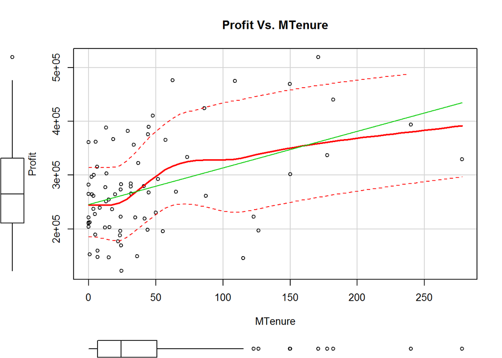

```r
library(car)
scatterplot(store.df$Profit~store.df$MTenure , xlab="MTenure", ylab="Profit", main="Profit Vs. MTenure", , labels=row.names(store.df))
```

# TASK 4h - Scatter Plots (contd.)

7. Use R to draw a scatter plot of Profit vs. CTenure.

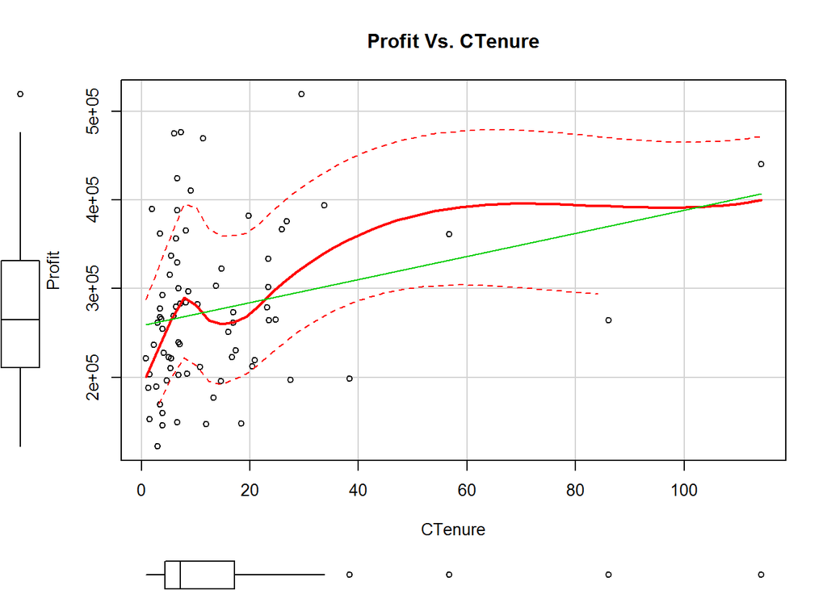

```r
scatterplot(store.df$Profit~store.df$CTenure , xlab="CTenure", ylab="Profit", main="Profit Vs. CTenure", , labels=row.names(store.df))
```

# TASK 4i - Correlation Matrix

8. Use R to construct a Correlation Matrix for all the variables in the dataset. (Display the numbers up to 2 Decimal places)

```r
cor <- cor(store.df)
round(cor,2)
```

```
##            store Sales Profit MTenure CTenure   Pop  Comp Visibility
## store       1.00 -0.23  -0.20   -0.06    0.02 -0.29  0.03      -0.03
## Sales      -0.23  1.00   0.92    0.45    0.25  0.40 -0.24       0.13
## Profit     -0.20  0.92   1.00    0.44    0.26  0.43 -0.33       0.14
## MTenure    -0.06  0.45   0.44    1.00    0.24 -0.06  0.18       0.16
## CTenure     0.02  0.25   0.26    0.24    1.00  0.00 -0.07       0.07
## Pop        -0.29  0.40   0.43   -0.06    0.00  1.00 -0.27      -0.05
## Comp        0.03 -0.24  -0.33    0.18   -0.07 -0.27  1.00       0.03
## Visibility -0.03  0.13   0.14    0.16    0.07 -0.05  0.03       1.00
## PedCount   -0.22  0.42   0.45    0.06   -0.08  0.61 -0.15      -0.14
## Res        -0.03 -0.17  -0.16   -0.06   -0.34 -0.24  0.22       0.02
## Hours24     0.03  0.06  -0.03   -0.17    0.07 -0.22  0.13       0.05
## CrewSkill   0.05  0.16   0.16    0.10    0.26  0.28 -0.04      -0.20
## MgrSkill   -0.07  0.31   0.32    0.23    0.12  0.08  0.22       0.07
## ServQual   -0.32  0.39   0.36    0.18    0.08  0.12  0.02       0.21
##            PedCount   Res Hours24 CrewSkill MgrSkill ServQual
## store         -0.22 -0.03    0.03      0.05    -0.07    -0.32
## Sales          0.42 -0.17    0.06      0.16     0.31     0.39
## Profit         0.45 -0.16   -0.03      0.16     0.32     0.36
## MTenure        0.06 -0.06   -0.17      0.10     0.23     0.18
## CTenure       -0.08 -0.34    0.07      0.26     0.12     0.08
## Pop            0.61 -0.24   -0.22      0.28     0.08     0.12
## Comp          -0.15  0.22    0.13     -0.04     0.22     0.02
## Visibility    -0.14  0.02    0.05     -0.20     0.07     0.21
## PedCount       1.00 -0.28   -0.28      0.21     0.09    -0.01
## Res           -0.28  1.00   -0.09     -0.15    -0.03     0.09
## Hours24       -0.28 -0.09    1.00      0.11    -0.04     0.06
## CrewSkill      0.21 -0.15    0.11      1.00    -0.02    -0.03
## MgrSkill       0.09 -0.03   -0.04     -0.02     1.00     0.36
## ServQual      -0.01  0.09    0.06     -0.03     0.36     1.00
```

# TASK 4j - Correlations

9. Use R to measure the correlation between Profit and MTenure. (Display the numbers up to 2 Decimal places)

```r
round(cor(Profit,MTenure),2)
```

```
## [1] 0.44
```

10. Use R to measure the correlation between Profit and CTenure. (Display the numbers up to 2 Decimal places)

```r
round(cor(Profit,CTenure),2)
```

```
## [1] 0.26
```

# TASK 4k

11. Use R to construct the following Corrgram based on all variables in the dataset.

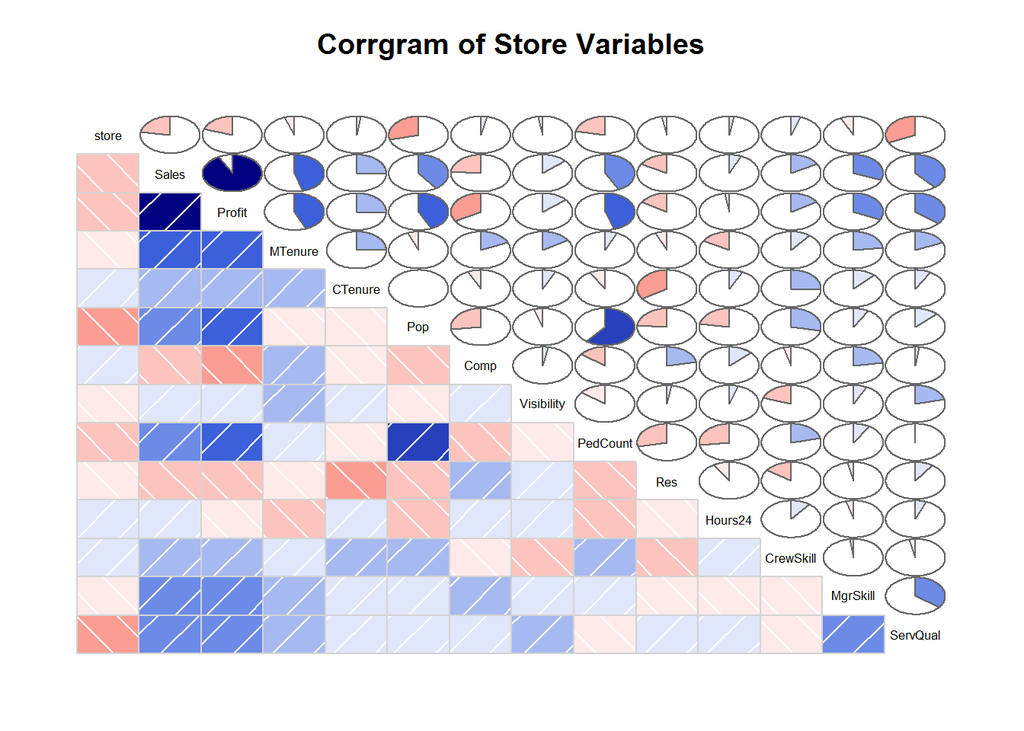

```r
library(corrgram)

corrgram(store.df, lower.panel=panel.shade,upper.panel=panel.pie, text.panel=panel.txt,main="Corrgram of Store Variables")
```

# TASK 4l - Pearson’s Correlation Tests

12. Run a Pearson’s Correlation test on the correlation between Profit and MTenure. What is the p-value?

```r
cor.test(store.df$Profit,store.df$MTenure)
```

```
##
##  Pearson's product-moment correlation
##
## data:  store.df$Profit and store.df$MTenure
## t = 4.1731, df = 73, p-value = 8.193e-05
## alternative hypothesis: true correlation is not equal to 0
## 95 percent confidence interval:
##  0.2353497 0.6055175
## sample estimates:
##       cor
## 0.4388692
```

The p-value is = 8.193e-05

13.Run a Pearson’s Correlation test on the correlation between Profit and CTenure. What is the p-value?

```r
cor.test(store.df$Profit,store.df$CTenure)
```

```
##
##  Pearson's product-moment correlation
##
## data:  store.df$Profit and store.df$CTenure
## t = 2.2786, df = 73, p-value = 0.02562
## alternative hypothesis: true correlation is not equal to 0
## 95 percent confidence interval:
##  0.03262507 0.45786339
## sample estimates:
##       cor
## 0.2576789
```

The p-value is = 0.02562

# TASK 4m - Regression Analysis

14. Run a regression of Profit on {MTenure, CTenure Comp, Pop, PedCount, Res, Hours24, Visibility}.

```r
profit <- lm(Profit ~ MTenure + CTenure + Comp + Pop + PedCount + Res + Hours24 + Visibility, data = store.df)
summary(profit)
```

```
##
## Call:
## lm(formula = Profit ~ MTenure + CTenure + Comp + Pop + PedCount +
##     Res + Hours24 + Visibility, data = store.df)
##
## Residuals:
##     Min      1Q  Median      3Q     Max
## -105789  -35946   -7069   33780  112390
##
## Coefficients:
##               Estimate Std. Error t value Pr(>|t|)
## (Intercept)   7610.041  66821.994   0.114 0.909674
## MTenure        760.993    127.086   5.988 9.72e-08 ***
## CTenure        944.978    421.687   2.241 0.028400 *
## Comp        -25286.887   5491.937  -4.604 1.94e-05 ***
## Pop              3.667      1.466   2.501 0.014890 *
## PedCount     34087.359   9073.196   3.757 0.000366 ***
## Res          91584.675  39231.283   2.334 0.022623 *
## Hours24      63233.307  19641.114   3.219 0.001994 **
## Visibility   12625.447   9087.620   1.389 0.169411
## ---
## Signif. codes:  0 '***' 0.001 '**' 0.01 '*' 0.05 '.' 0.1 ' ' 1
##
## Residual standard error: 56970 on 66 degrees of freedom
## Multiple R-squared:  0.6379, Adjusted R-squared:  0.594
## F-statistic: 14.53 on 8 and 66 DF,  p-value: 5.382e-12
```

TASK 4n Based on TASK 4m, answer the following questions:

15. List the explanatory variable(s) whose beta-coefficients are statistically significant (p < 0.05).

MTenure (9.72e-08), CTenure (0.028400), Comp (1.94e-05), Pop (0.014890), PedCount (0.000366), Res (0.022623), Hours24 (0.001994).

16. List the explanatory variable(s) whose beta-coefficients are not statistically significant(p > 0.05). Visibility (0.169411)

# TASK 4o

17. What is expected change in the Profit at a store, if the Manager’s tenure i.e. number of months of experience with Store24, increases by one month?

```r
profit$coefficients[2]
```

```
##  MTenure
## 760.9927
```

18. What is expected change in the Profit at a store, if the Crew’s tenure i.e. number of months of experience with Store24, increases by one month?

```r
profit$coefficients[3]
```

```
## CTenure
## 944.978
```

# TASK 4p - “Executive Summary”

1. The given data set of store24 has 75 observations and 14 variables.
2. The maximun profit of a given stores is 518998 and the least profit is 122180. From the above analysis, we can say that the 10 most profitable stores have higher manager tenures and crew tenures than the 10 least profitable stores.
3. The correlation between profit and sales is the maximum. (Corrgram) Other variables like ManagerTenure, CrewTenure also affect the profit which we can see by conducting the correlations test.
4. In the Regression test, the p-value of the F-statistic is < 0.05 significantly, which means it is suitable for deriving decisions from the data. The visibility factor has a beta-coefficient > 0.05 and is not very significant statistically.
5. By regression, there’s a very high relationship of MTenure and pedcount with profit, a negative relationship between profits and competitors and a good relationship between profits and hours,CTenure,population and residence. So, to maximise profit of the store, one must focus on increasing/decreasing those factors/variables that help increase/decrease the profit of the store.